# Final Project - Predicting PDAC with Circulating miRNA - Multi-miRNA and Consensus Feature Analysis

2026-04-28

# Multi-miRNA and Consensus Feature Analysis

This report loads the saved consensus-feature inputs written by the main PDAC modeling report and performs the downstream multiMiR and final consensus-feature summary analysis separately.

## Top-ranked Consensus miRNAs

Loaded downstream consensus-feature inputs from Data/Top-ranked consensus miRNA downstream inputs.rds. Top-rank selection count: 4 non-tree models.

Top-ranked consensus miRNAs from the non-tree models

| miRNA | Annotation | n_models_selected | limma_log_fc | limma_t | limma_p_value | limma_adj_p_value |
| --- | --- | --- | --- | --- | --- | --- |
| MIMAT0018443 | hsa-miR-374c-5p | 4 | 0.1311806 | 4.098444 | 0.0000432 | 0.0343759 |
| MIMAT0017982 | hsa-miR-3605-3p | 4 | 0.0512284 | 3.658686 | 0.0002598 | 0.1012441 |
| MIMAT0000063 | hsa-let-7b-5p | 4 | -0.1539616 | -3.481557 | 0.0005088 | 0.1012441 |
| MIMAT0014994 | hsa-miR-3130-3p | 4 | 0.1448238 | 3.376303 | 0.0007481 | 0.1191043 |
| MIMAT0003313 | hsa-miR-643 | 4 | 0.1044217 | 2.880852 | 0.0040065 | 0.1779830 |
| MIMAT0005914 | hsa-miR-1262 | 4 | 0.1790189 | 2.873848 | 0.0040961 | 0.1779830 |
| MIMAT0006764 | hsa-miR-320d | 4 | 0.0460200 | 2.864066 | 0.0042242 | 0.1779830 |
| MIMAT0003268 | hsa-miR-600 | 4 | 0.0750287 | 2.847763 | 0.0044459 | 0.1779830 |
| MIMAT0015058 | hsa-miR-3180-3p | 4 | 0.1250512 | 2.842712 | 0.0045167 | 0.1779830 |

## Merged miRNA Set for Downstream multiMiR Queries

The downstream multiMiR query set contains 15 merged top miRNA features drawn from the consensus, decision-tree, and random-forest rankings.

Merged top miRNA features with derived multiMiR query identifiers

| miRNA | Annotation | multiMiR_query_id |
| --- | --- | --- |
| MIMAT0018443 | hsa-miR-374c-5p | hsa-miR-374c-5p |
| MIMAT0017982 | hsa-miR-3605-3p | hsa-miR-3605-3p |
| MIMAT0000063 | hsa-let-7b-5p | hsa-let-7b-5p |
| MIMAT0014994 | hsa-miR-3130-3p | hsa-miR-3130-3p |
| MIMAT0003313 | hsa-miR-643 | hsa-miR-643 |
| MIMAT0000687 | hsa-miR-299-3p | hsa-miR-299-3p |
| MIMAT0000261 | hsa-miR-183-5p | hsa-miR-183-5p |
| MIMAT0015050 | hsa-miR-323b-3p | hsa-miR-323b-3p |
| MIMAT0003161 | hsa-miR-493-3p | hsa-miR-493-3p |
| MIMAT0001545 | hsa-miR-450a-5p | hsa-miR-450a-5p |
| MIMAT0001631 | hsa-miR-451a | hsa-miR-451a |
| MIMAT0003237 | hsa-miR-572 | hsa-miR-572 |
| MIMAT0004949 | hsa-miR-877-5p | hsa-miR-877-5p |
| MIMAT0000095 | hsa-miR-96-5p | hsa-miR-96-5p |
| MIMAT0018119 | hsa-miR-3690 | hsa-miR-3690 |

## miRNA Interactions

Assess validated target and disease/drug associations for the merged top-ranked miRNA set with multiMiR.

multiMiR query miRNAs: hsa-miR-374c-5p, hsa-miR-3605-3p, hsa-let-7b-5p, hsa-miR-3130-3p, hsa-miR-643, hsa-miR-3690, hsa-miR-493-3p, hsa-miR-451a, hsa-miR-450a-5p, hsa-miR-877-5p, hsa-miR-183-5p, hsa-miR-572, hsa-miR-96-5p, hsa-miR-299-3p, and hsa-miR-323b-3p

Validated multiMiR target-protein records for the merged top-feature miRNA set

| miRNA | Annotation | multiMiR_query_id | target_symbol | target_entrez | target_ensembl | database |
| --- | --- | --- | --- | --- | --- | --- |
| MIMAT0018443 | hsa-miR-374c-5p | hsa-miR-374c-5p | CAPRIN2 | 65981 | ENSG00000110888 | mirtarbase |
| MIMAT0018443 | hsa-miR-374c-5p | hsa-miR-374c-5p | CAPRIN2 | 65981 | ENSG00000110888 | mirtarbase |
| MIMAT0018443 | hsa-miR-374c-5p | hsa-miR-374c-5p | CAPRIN2 | 65981 | ENSG00000110888 | mirtarbase |
| MIMAT0018443 | hsa-miR-374c-5p | hsa-miR-374c-5p | CAPRIN2 | 65981 | ENSG00000110888 | mirtarbase |
| MIMAT0018443 | hsa-miR-374c-5p | hsa-miR-374c-5p | TRIM2 | 23321 | ENSG00000109654 | mirtarbase |
| MIMAT0018443 | hsa-miR-374c-5p | hsa-miR-374c-5p | TRIM2 | 23321 | ENSG00000109654 | mirtarbase |
| MIMAT0018443 | hsa-miR-374c-5p | hsa-miR-374c-5p | TRIM2 | 23321 | ENSG00000109654 | mirtarbase |
| MIMAT0018443 | hsa-miR-374c-5p | hsa-miR-374c-5p | TRIM2 | 23321 | ENSG00000109654 | mirtarbase |
| MIMAT0018443 | hsa-miR-374c-5p | hsa-miR-374c-5p | HIPK3 | 10114 | ENSG00000110422 | mirtarbase |
| MIMAT0018443 | hsa-miR-374c-5p | hsa-miR-374c-5p | HIPK3 | 10114 | ENSG00000110422 | mirtarbase |
| MIMAT0018443 | hsa-miR-374c-5p | hsa-miR-374c-5p | JUN | 3725 | ENSG00000177606 | mirtarbase |
| MIMAT0018443 | hsa-miR-374c-5p | hsa-miR-374c-5p | JUN | 3725 | ENSG00000177606 | mirtarbase |
| MIMAT0018443 | hsa-miR-374c-5p | hsa-miR-374c-5p | CYP1A1 | 1543 | ENSG00000140465 | mirtarbase |
| MIMAT0018443 | hsa-miR-374c-5p | hsa-miR-374c-5p | CYP1A1 | 1543 | ENSG00000140465 | mirtarbase |
| MIMAT0018443 | hsa-miR-374c-5p | hsa-miR-374c-5p | BCL2L11 | 10018 | ENSG00000153094 | mirtarbase |

Validated multiMiR interaction records across the merged top-feature miRNA set: 38603; unique target genes: 13331; queried miRNAs with validated targets: 15 of 15

Top validated multiMiR targets for the merged top-feature miRNA set

| miRNA | Annotation | multiMiR_query_id | n_models_selected | target_symbol | target_entrez | target_ensembl | validated_support | total_support |
| --- | --- | --- | --- | --- | --- | --- | --- | --- |
| MIMAT0000063 | hsa-let-7b-5p | hsa-let-7b-5p | 4 | BCL7A | 605 | ENSG00000110987 | 3 | 3 |
| MIMAT0000063 | hsa-let-7b-5p | hsa-let-7b-5p | 4 | CCND1 | 595 | ENSG00000110092 | 3 | 3 |
| MIMAT0000063 | hsa-let-7b-5p | hsa-let-7b-5p | 4 | CDC25A | 993 | ENSG00000164045 | 3 | 3 |
| MIMAT0000063 | hsa-let-7b-5p | hsa-let-7b-5p | 4 | CDC34 | 997 | ENSG00000099804 | 3 | 3 |
| MIMAT0000063 | hsa-let-7b-5p | hsa-let-7b-5p | 4 | CDK6 | 1021 | ENSG00000105810 | 3 | 3 |
| MIMAT0000063 | hsa-let-7b-5p | hsa-let-7b-5p | 4 | HMGA2 | 8091 | ENSG00000149948 | 3 | 3 |
| MIMAT0000063 | hsa-let-7b-5p | hsa-let-7b-5p | 4 | ABCB10 | 23456 | ENSG00000135776 | 2 | 2 |
| MIMAT0000063 | hsa-let-7b-5p | hsa-let-7b-5p | 4 | ABCB8 | 11194 | ENSG00000197150 | 2 | 2 |
| MIMAT0000063 | hsa-let-7b-5p | hsa-let-7b-5p | 4 | ABCF1 | 23 | ENSG00000204574 | 2 | 2 |
| MIMAT0000063 | hsa-let-7b-5p | hsa-let-7b-5p | 4 | ABHD17C | 58489 | ENSG00000136379 | 2 | 2 |
| MIMAT0000063 | hsa-let-7b-5p | hsa-let-7b-5p | 4 | ABL1 | 25 | ENSG00000097007 | 2 | 2 |
| MIMAT0000063 | hsa-let-7b-5p | hsa-let-7b-5p | 4 | ACACA | 31 | ENSG00000278540 | 2 | 2 |
| MIMAT0000063 | hsa-let-7b-5p | hsa-let-7b-5p | 4 | ACER2 | 340485 | ENSG00000177076 | 2 | 2 |
| MIMAT0000063 | hsa-let-7b-5p | hsa-let-7b-5p | 4 | ACOT9 | 23597 | ENSG00000123130 | 2 | 2 |
| MIMAT0000063 | hsa-let-7b-5p | hsa-let-7b-5p | 4 | ACP3 | 55 | ENSG00000014257 | 2 | 2 |

multiMiR disease/drug association records across the merged top-feature miRNA set: 244; unique association terms: 91; queried miRNAs with disease/drug associations: 9 of 15

Top multiMiR disease/drug associations for the merged top-feature miRNA set

| miRNA | Annotation | multiMiR_query_id | n_models_selected | disease_drug | n_records | n_databases | n_pubmed |
| --- | --- | --- | --- | --- | --- | --- | --- |
| MIMAT0000063 | hsa-let-7b-5p | hsa-let-7b-5p | 4 | Cancer | 4 | 1 | 4 |
| MIMAT0000063 | hsa-let-7b-5p | hsa-let-7b-5p | 4 | Hepatocellular carcinoma | 3 | 1 | 3 |
| MIMAT0000063 | hsa-let-7b-5p | hsa-let-7b-5p | 4 | Muscular | 3 | 1 | 3 |
| MIMAT0000063 | hsa-let-7b-5p | hsa-let-7b-5p | 4 | Ovarian cancer | 3 | 1 | 3 |
| MIMAT0000063 | hsa-let-7b-5p | hsa-let-7b-5p | 4 | Breast cancer | 2 | 1 | 2 |
| MIMAT0000063 | hsa-let-7b-5p | hsa-let-7b-5p | 4 | Cardiomyopathy, dilated | 2 | 1 | 2 |
| MIMAT0000063 | hsa-let-7b-5p | hsa-let-7b-5p | 4 | Colorectal cancer | 2 | 1 | 2 |
| MIMAT0000063 | hsa-let-7b-5p | hsa-let-7b-5p | 4 | Leukemia, acute myeloid | 2 | 1 | 2 |
| MIMAT0000063 | hsa-let-7b-5p | hsa-let-7b-5p | 4 | lung cancer | 2 | 1 | 2 |
| MIMAT0000063 | hsa-let-7b-5p | hsa-let-7b-5p | 4 | Lung cancer | 2 | 1 | 2 |
| MIMAT0000063 | hsa-let-7b-5p | hsa-let-7b-5p | 4 | Melanoma and neural system tumor syndrome | 2 | 1 | 2 |
| MIMAT0000063 | hsa-let-7b-5p | hsa-let-7b-5p | 4 | Neuroblastoma | 2 | 1 | 2 |
| MIMAT0000063 | hsa-let-7b-5p | hsa-let-7b-5p | 4 | Prostate cancer | 2 | 1 | 2 |
| MIMAT0000063 | hsa-let-7b-5p | hsa-let-7b-5p | 4 | acute lymphoblastic leukemia (ALL) | 1 | 1 | 1 |
| MIMAT0000063 | hsa-let-7b-5p | hsa-let-7b-5p | 4 | acute myeloid leukemia (AML) | 1 | 1 | 1 |

## Shared Validated multiMiR Target Genes

Summarize validated target genes across the saved multiMiR results object for the merged top-feature miRNA set.

Loaded saved multiMiR results from Data/Top-ranked consensus miRNA multiMiR results.rds and summarized 13331 validated target genes across 15 queried merged top-feature miRNAs.

Validated target genes shared across the merged top-feature miRNA set

| target_symbol | target_entrez | target_ensembl | n_consensus_miRNA | consensus_miRNA | total_validated_support | total_support | max_models_selected |
| --- | --- | --- | --- | --- | --- | --- | --- |
| ZZZ3 | 26009 | ENSG00000036549 | 11 | hsa-let-7b-5p, hsa-miR-183-5p, hsa-miR-299-3p, hsa-miR-3130-3p, hsa-miR-323b-3p, hsa-miR-3690, hsa-miR-374c-5p, hsa-miR-451a, hsa-miR-572, hsa-miR-877-5p, and hsa-miR-96-5p | 12 | 12 | 4 |
| DYNC1H1 | 1778 | ENSG00000197102 | 9 | hsa-let-7b-5p, hsa-miR-183-5p, hsa-miR-299-3p, hsa-miR-3605-3p, hsa-miR-450a-5p, hsa-miR-451a, hsa-miR-493-3p, hsa-miR-877-5p, and hsa-miR-96-5p | 11 | 11 | 4 |
| HIF1A | 3091 | ENSG00000100644 | 9 | hsa-let-7b-5p, hsa-miR-183-5p, hsa-miR-299-3p, hsa-miR-374c-5p, hsa-miR-450a-5p, hsa-miR-493-3p, hsa-miR-643, hsa-miR-877-5p, and hsa-miR-96-5p | 10 | 10 | 4 |
| CLTC | 1213 | ENSG00000141367 | 9 | hsa-let-7b-5p, hsa-miR-183-5p, hsa-miR-299-3p, hsa-miR-3605-3p, hsa-miR-450a-5p, hsa-miR-451a, hsa-miR-493-3p, hsa-miR-877-5p, and hsa-miR-96-5p | 9 | 9 | 4 |
| SPTBN1 | 6711 | ENSG00000115306 | 9 | hsa-let-7b-5p, hsa-miR-183-5p, hsa-miR-299-3p, hsa-miR-323b-3p, hsa-miR-450a-5p, hsa-miR-451a, hsa-miR-493-3p, hsa-miR-877-5p, and hsa-miR-96-5p | 9 | 9 | 4 |
| CCND1 | 595 | ENSG00000110092 | 8 | hsa-let-7b-5p, hsa-miR-183-5p, hsa-miR-323b-3p, hsa-miR-450a-5p, hsa-miR-451a, hsa-miR-493-3p, hsa-miR-877-5p, and hsa-miR-96-5p | 12 | 12 | 4 |
| ATP2A2 | 488 | ENSG00000174437 | 8 | hsa-let-7b-5p, hsa-miR-183-5p, hsa-miR-3605-3p, hsa-miR-450a-5p, hsa-miR-451a, hsa-miR-493-3p, hsa-miR-877-5p, and hsa-miR-96-5p | 9 | 9 | 4 |
| BAZ1B | 9031 | ENSG00000009954 | 8 | hsa-let-7b-5p, hsa-miR-183-5p, hsa-miR-299-3p, hsa-miR-3605-3p, hsa-miR-450a-5p, hsa-miR-493-3p, hsa-miR-877-5p, and hsa-miR-96-5p | 9 | 9 | 4 |
| PRPF8 | 10594 | ENSG00000174231 | 8 | hsa-let-7b-5p, hsa-miR-183-5p, hsa-miR-323b-3p, hsa-miR-3605-3p, hsa-miR-450a-5p, hsa-miR-493-3p, hsa-miR-877-5p, and hsa-miR-96-5p | 9 | 9 | 4 |
| THBS1 | 7057 | ENSG00000137801 | 8 | hsa-let-7b-5p, hsa-miR-183-5p, hsa-miR-299-3p, hsa-miR-3605-3p, hsa-miR-450a-5p, hsa-miR-643, hsa-miR-877-5p, and hsa-miR-96-5p | 9 | 9 | 4 |
| FLNB | 2317 | ENSG00000136068 | 8 | hsa-let-7b-5p, hsa-miR-183-5p, hsa-miR-3605-3p, hsa-miR-450a-5p, hsa-miR-451a, hsa-miR-493-3p, hsa-miR-877-5p, and hsa-miR-96-5p | 8 | 8 | 4 |
| FN1 | 2335 | ENSG00000115414 | 8 | hsa-let-7b-5p, hsa-miR-183-5p, hsa-miR-323b-3p, hsa-miR-450a-5p, hsa-miR-451a, hsa-miR-493-3p, hsa-miR-877-5p, and hsa-miR-96-5p | 8 | 8 | 4 |
| KMT2C | 58508 | ENSG00000055609 | 8 | hsa-let-7b-5p, hsa-miR-183-5p, hsa-miR-299-3p, hsa-miR-450a-5p, hsa-miR-493-3p, hsa-miR-643, hsa-miR-877-5p, and hsa-miR-96-5p | 8 | 8 | 4 |
| MAP1B | 4131 | ENSG00000131711 | 8 | hsa-let-7b-5p, hsa-miR-183-5p, hsa-miR-299-3p, hsa-miR-450a-5p, hsa-miR-451a, hsa-miR-493-3p, hsa-miR-877-5p, and hsa-miR-96-5p | 8 | 8 | 4 |
| MYH9 | 4627 | ENSG00000100345 | 8 | hsa-let-7b-5p, hsa-miR-183-5p, hsa-miR-299-3p, hsa-miR-3605-3p, hsa-miR-450a-5p, hsa-miR-493-3p, hsa-miR-877-5p, and hsa-miR-96-5p | 8 | 8 | 4 |
| NR3C1 | 2908 | ENSG00000113580 | 8 | hsa-let-7b-5p, hsa-miR-183-5p, hsa-miR-3130-3p, hsa-miR-450a-5p, hsa-miR-451a, hsa-miR-643, hsa-miR-877-5p, and hsa-miR-96-5p | 8 | 8 | 4 |
| PRKAA1 | 5562 | ENSG00000132356 | 8 | hsa-let-7b-5p, hsa-miR-183-5p, hsa-miR-299-3p, hsa-miR-3690, hsa-miR-450a-5p, hsa-miR-451a, hsa-miR-877-5p, and hsa-miR-96-5p | 8 | 8 | 4 |
| PRRC2C | 23215 | ENSG00000117523 | 8 | hsa-let-7b-5p, hsa-miR-183-5p, hsa-miR-299-3p, hsa-miR-3605-3p, hsa-miR-450a-5p, hsa-miR-451a, hsa-miR-877-5p, and hsa-miR-96-5p | 8 | 8 | 4 |
| DST | 667 | ENSG00000151914 | 8 | hsa-let-7b-5p, hsa-miR-183-5p, hsa-miR-3130-3p, hsa-miR-3605-3p, hsa-miR-450a-5p, hsa-miR-451a, hsa-miR-877-5p, and hsa-miR-96-5p | 7 | 7 | 4 |
| SMG1 | 23049 | ENSG00000157106 | 7 | hsa-let-7b-5p, hsa-miR-183-5p, hsa-miR-450a-5p, hsa-miR-451a, hsa-miR-643, hsa-miR-877-5p, and hsa-miR-96-5p | 10 | 10 | 4 |

## GO Terms for Validated multiMiR Target Proteins

Use the validated multiMiR target-protein set to run GO biological-process enrichment, following the same downstream biology emphasis as your teammate’s selected analysis.

GO biological-process enrichment for validated multiMiR target proteins

| ID | Description | GeneRatio | BgRatio | RichFactor | FoldEnrichment | zScore | pvalue | p.adjust | qvalue | geneID | Count |
| --- | --- | --- | --- | --- | --- | --- | --- | --- | --- | --- | --- |
| GO:0010975 | regulation of neuron projection development | 406/12228 | 448/18860 | 0.906 | 1.398 | 11.570 | 0 | 0 | 0 | 65981/5663/23271/440730/54915/659/2045/23077/53335/7431/2341…… | 406 |
| GO:0051052 | regulation of DNA metabolic process | 440/12228 | 497/18860 | 0.885 | 1.365 | 11.212 | 0 | 0 | 0 | 7465/26354/56907/144455/151987/1956/23381/60/1676/2305/3320/…… | 440 |
| GO:0016236 | macroautophagy | 363/12228 | 403/18860 | 0.901 | 1.389 | 10.726 | 0 | 0 | 0 | 5663/23265/55432/143686/51534/3091/160760/488/550/5768/6829/…… | 363 |
| GO:0048193 | Golgi vesicle transport | 292/12228 | 319/18860 | 0.915 | 1.412 | 10.073 | 0 | 0 | 0 | 56907/9321/5876/7531/10890/10484/10749/286451/9341/5587/372/…… | 292 |
| GO:0050803 | regulation of synapse structure or activity | 300/12228 | 329/18860 | 0.912 | 1.406 | 10.098 | 0 | 0 | 0 | 65981/3799/5663/5879/8828/2045/23077/29843/22865/387/4076/47…… | 300 |
| GO:0072657 | protein localization to membrane | 401/12228 | 458/18860 | 0.876 | 1.350 | 10.308 | 0 | 0 | 0 | 3799/5879/10890/22865/1956/60/1213/1742/2316/3675/8878/10484…… | 401 |
| GO:0050807 | regulation of synapse organization | 294/12228 | 322/18860 | 0.913 | 1.408 | 10.033 | 0 | 0 | 0 | 65981/3799/5663/5879/8828/2045/23077/29843/22865/387/4076/47…… | 294 |
| GO:0140694 | membraneless organelle assembly | 384/12228 | 446/18860 | 0.861 | 1.328 | 9.517 | 0 | 0 | 0 | 54915/29777/6125/6194/253943/7072/387/4076/550/1778/2316/388…… | 384 |
| GO:0140014 | mitotic nuclear division | 254/12228 | 281/18860 | 0.904 | 1.394 | 9.039 | 0 | 0 | 0 | 7329/387/2316/4041/9031/27183/128866/57132/8243/3796/1027/65…… | 254 |
| GO:0051056 | regulation of small GTPase mediated signal transduction | 280/12228 | 314/18860 | 0.892 | 1.375 | 9.107 | 0 | 0 | 0 | 5879/440730/395/23362/4853/2305/3675/8878/57148/64759/84033/…… | 280 |
| GO:0060560 | developmental growth involved in morphogenesis | 226/12228 | 246/18860 | 0.919 | 1.417 | 8.938 | 0 | 0 | 0 | 7022/8828/659/2045/53335/4133/6299/6495/50618/54413/91584/48…… | 226 |
| GO:0000209 | protein polyubiquitination | 265/12228 | 300/18860 | 0.883 | 1.362 | 8.592 | 0 | 0 | 0 | 23321/81844/7531/23077/6500/23608/55585/8878/10075/51366/559…… | 265 |
| GO:0008654 | phospholipid biosynthetic process | 229/12228 | 255/18860 | 0.898 | 1.385 | 8.407 | 0 | 0 | 0 | 1606/3157/5277/94005/5338/20/5297/3636/3422/5130/5155/5336/5…… | 229 |
| GO:0042254 | ribosome biogenesis | 276/12228 | 318/18860 | 0.868 | 1.339 | 8.270 | 0 | 0 | 0 | 84135/11056/29777/6218/6125/6194/6175/9188/29102/55299/54505…… | 276 |
| GO:0060562 | epithelial tube morphogenesis | 295/12228 | 344/18860 | 0.858 | 1.323 | 8.201 | 0 | 0 | 0 | 133/5663/6497/7022/8323/3091/2045/7976/55366/5420/84678/4853…… | 295 |

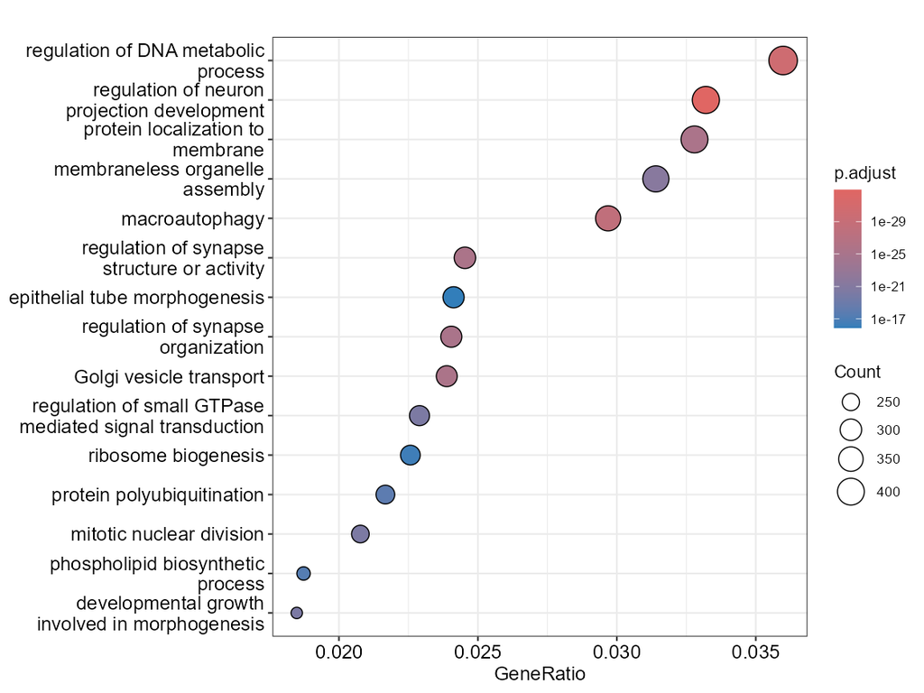

## Shared multiMiR Disease/Drug Terms

Summarize disease/drug terms across the saved multiMiR results object for the merged top-feature miRNA set.

Loaded saved multiMiR results from Data/Top-ranked consensus miRNA multiMiR results.rds and summarized 91 disease/drug terms across 15 queried merged top-feature miRNAs.

Disease/drug terms shared across the merged top-feature miRNA set

| disease_drug | n_consensus_miRNA | consensus_miRNA | total_records | total_databases | total_pubmed | max_models_selected |
| --- | --- | --- | --- | --- | --- | --- |
| Ovarian cancer | 7 | hsa-let-7b-5p, hsa-miR-183-5p, hsa-miR-299-3p, hsa-miR-451a, hsa-miR-493-3p, hsa-miR-572, and hsa-miR-96-5p | 12 | 7 | 12 | 4 |
| Cancer | 6 | hsa-let-7b-5p, hsa-miR-183-5p, hsa-miR-299-3p, hsa-miR-450a-5p, hsa-miR-877-5p, and hsa-miR-96-5p | 12 | 6 | 12 | 4 |
| Breast cancer | 6 | hsa-let-7b-5p, hsa-miR-183-5p, hsa-miR-299-3p, hsa-miR-451a, hsa-miR-493-3p, and hsa-miR-96-5p | 8 | 6 | 8 | 4 |
| Lung cancer | 5 | hsa-let-7b-5p, hsa-miR-183-5p, hsa-miR-299-3p, hsa-miR-451a, and hsa-miR-96-5p | 10 | 5 | 10 | 4 |
| Melanoma and neural system tumor syndrome | 5 | hsa-let-7b-5p, hsa-miR-183-5p, hsa-miR-299-3p, hsa-miR-493-3p, and hsa-miR-96-5p | 9 | 5 | 9 | 4 |
| Leukemia, acute myeloid | 5 | hsa-let-7b-5p, hsa-miR-299-3p, hsa-miR-450a-5p, hsa-miR-451a, and hsa-miR-493-3p | 7 | 5 | 7 | 4 |
| Muscular | 5 | hsa-let-7b-5p, hsa-miR-299-3p, hsa-miR-451a, hsa-miR-493-3p, and hsa-miR-96-5p | 7 | 5 | 7 | 4 |
| Hematological | 5 | hsa-let-7b-5p, hsa-miR-183-5p, hsa-miR-299-3p, hsa-miR-451a, and hsa-miR-96-5p | 5 | 5 | 5 | 4 |
| Stroke, susceptibility to | 5 | hsa-let-7b-5p, hsa-miR-183-5p, hsa-miR-299-3p, hsa-miR-451a, and hsa-miR-877-5p | 5 | 5 | 5 | 4 |
| Colorectal cancer | 4 | hsa-let-7b-5p, hsa-miR-183-5p, hsa-miR-299-3p, and hsa-miR-96-5p | 8 | 4 | 8 | 4 |
| Hepatocellular carcinoma | 4 | hsa-let-7b-5p, hsa-miR-183-5p, hsa-miR-299-3p, and hsa-miR-96-5p | 8 | 4 | 8 | 4 |
| colorectal cancer | 4 | hsa-let-7b-5p, hsa-miR-183-5p, hsa-miR-451a, and hsa-miR-96-5p | 7 | 4 | 7 | 4 |
| Pancreatic cancer | 4 | hsa-let-7b-5p, hsa-miR-183-5p, hsa-miR-299-3p, and hsa-miR-96-5p | 6 | 4 | 6 | 4 |
| Squamous cell carcinoma, head and neck | 4 | hsa-let-7b-5p, hsa-miR-183-5p, hsa-miR-299-3p, and hsa-miR-96-5p | 6 | 4 | 6 | 4 |
| Prostate cancer | 4 | hsa-let-7b-5p, hsa-miR-183-5p, hsa-miR-299-3p, and hsa-miR-96-5p | 5 | 4 | 5 | 4 |
| Glioblastoma multiforme, somatic | 3 | hsa-miR-183-5p, hsa-miR-299-3p, and hsa-miR-451a | 6 | 3 | 6 | 3 |
| lung cancer | 3 | hsa-let-7b-5p, hsa-miR-183-5p, and hsa-miR-451a | 6 | 3 | 6 | 4 |
| Gastric cancer | 3 | hsa-miR-183-5p, hsa-miR-451a, and hsa-miR-96-5p | 4 | 3 | 4 | 3 |
| Leukemia, chronic lymphatic, susceptibility to | 3 | hsa-let-7b-5p, hsa-miR-183-5p, and hsa-miR-96-5p | 4 | 3 | 4 | 4 |
| hepatocellular carcinoma (HCC) | 3 | hsa-let-7b-5p, hsa-miR-183-5p, and hsa-miR-96-5p | 4 | 3 | 4 | 4 |
| Cervical cancer, somatic | 3 | hsa-let-7b-5p, hsa-miR-183-5p, and hsa-miR-451a | 3 | 3 | 3 | 4 |
| Myopathy, nemaline, 3 | 3 | hsa-let-7b-5p, hsa-miR-299-3p, and hsa-miR-493-3p | 3 | 3 | 3 | 4 |
| malignant melanoma | 3 | hsa-let-7b-5p, hsa-miR-183-5p, and hsa-miR-96-5p | 3 | 3 | 3 | 4 |
| nemaline myopathy (NM) | 3 | hsa-let-7b-5p, hsa-miR-299-3p, and hsa-miR-493-3p | 3 | 3 | 3 | 4 |
| prostate cancer | 3 | hsa-let-7b-5p, hsa-miR-183-5p, and hsa-miR-96-5p | 3 | 3 | 3 | 4 |
| retinitis pigmentosa (RP) | 2 | hsa-miR-183-5p and hsa-miR-96-5p | 4 | 2 | 4 | 0 |
| Cardiomyopathy, dilated | 2 | hsa-let-7b-5p and hsa-miR-299-3p | 3 | 2 | 3 | 4 |
| Gastrointestinal | 2 | hsa-miR-183-5p and hsa-miR-96-5p | 3 | 2 | 3 | 0 |
| Duchenne muscular dystrophy | 2 | hsa-miR-299-3p and hsa-miR-493-3p | 2 | 2 | 2 | 3 |
| Duchenne muscular dystrophy (DMD) | 2 | hsa-miR-299-3p and hsa-miR-493-3p | 2 | 2 | 2 | 3 |

[output cut: 61 more lines]

# Final Summary Table of the Merged Top miRNA Features

A table of the merged top miRNA features with their blocked-limma statistics, non-tree model selection counts, and multiMiR summary counts.

Merged top miRNA feature summary

| miRNA | Annotation | mean_control | mean_case | mean_diff | limma_p_value | n_models_selected | n_target_genes | n_disease_drug_terms |
| --- | --- | --- | --- | --- | --- | --- | --- | --- |
| MIMAT0018443 | hsa-miR-374c-5p | 0.259 | 0.389 | 0.130 | 0.000 | 4 | 176 | 0 |
| MIMAT0017982 | hsa-miR-3605-3p | 0.036 | 0.087 | 0.051 | 0.000 | 4 | 313 | 0 |
| MIMAT0000063 | hsa-let-7b-5p | 5.246 | 5.091 | -0.155 | 0.001 | 4 | 11428 | 48 |
| MIMAT0014994 | hsa-miR-3130-3p | 0.617 | 0.761 | 0.144 | 0.001 | 4 | 83 | 0 |
| MIMAT0003313 | hsa-miR-643 | 0.421 | 0.525 | 0.105 | 0.004 | 4 | 145 | 0 |
| MIMAT0018119 | hsa-miR-3690 | 1.527 | 1.715 | 0.188 | 0.002 | 3 | 65 | 0 |
| MIMAT0003161 | hsa-miR-493-3p | 1.081 | 1.241 | 0.160 | 0.002 | 3 | 329 | 13 |
| MIMAT0001631 | hsa-miR-451a | 9.685 | 9.476 | -0.209 | 0.013 | 3 | 312 | 30 |
| MIMAT0001545 | hsa-miR-450a-5p | 0.750 | 0.861 | 0.112 | 0.015 | 3 | 3453 | 2 |
| MIMAT0004949 | hsa-miR-877-5p | 1.713 | 1.807 | 0.094 | 0.113 | 0 | 4710 | 2 |
| MIMAT0000261 | hsa-miR-183-5p | 3.668 | 3.768 | 0.100 | 0.116 | 0 | 6954 | 29 |
| MIMAT0003237 | hsa-miR-572 | 1.298 | 1.244 | -0.054 | 0.288 | 0 | 21 | 3 |
| MIMAT0000095 | hsa-miR-96-5p | 1.905 | 1.943 | 0.037 | 0.535 | 0 | 4664 | 34 |
| MIMAT0000687 | hsa-miR-299-3p | 1.400 | 1.369 | -0.031 | 0.540 | 0 | 382 | 25 |
| MIMAT0015050 | hsa-miR-323b-3p | 2.167 | 2.183 | 0.016 | 0.772 | 0 | 154 | 0 |

## Blocked-limma Summary Plot of Merged Top miRNA Features

Blocked-limma summary of the merged top miRNA feature set.

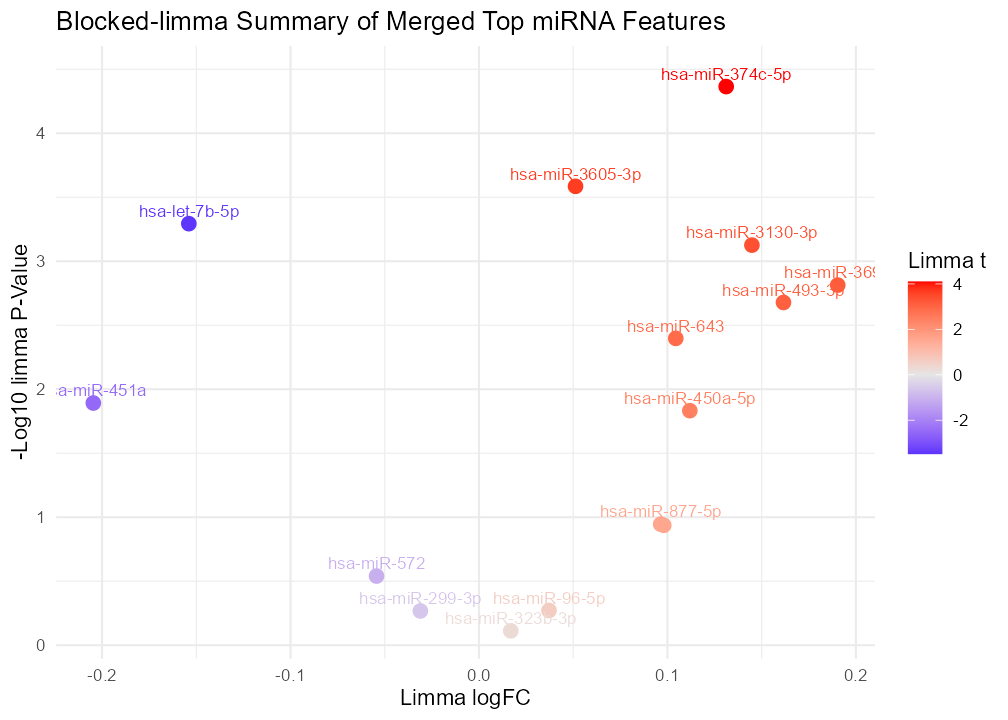

Report runtime: 00:08:51 (started 2026-04-28 22:50:03; finished 2026-04-28 22:58:54).